# PRAKTIKUM KOMPUTASI STATISTIK MODUL 1

Sella Dianka Fitri

2023-10-02

# Nama : Sella Dianka Fitri

# NIM : 121450043

# Kelas : RB

Paket ggplot2 digunakan untuk visualisasi data dengan kontrol tinggi, readr untuk mengimpor data dari format teks, dan dplyr untuk manipulasi data dengan efisien dalam lingkungan R.

```r
library(ggplot2)
library(readr)
library(dplyr)
```

Pertama kita akan memasukkan dataset kedalam dataframe “heart” setelah itu dilanjutkan dengan menampilkan 6 data teratas pada dataset menggunakan fungsi head()

```r
heart <- as.data.frame(read.csv("C:/Users/Lenovo/Downloads/Heart (2).csv"))
head(heart)
```

```
##   X Age Sex    ChestPain RestBP Chol Fbs RestECG MaxHR ExAng Oldpeak Slope Ca
## 1 1  63   1      typical    145  233   1       2   150     0     2.3     3  0
## 2 2  67   1 asymptomatic    160  286   0       2   108     1     1.5     2  3
## 3 3  67   1 asymptomatic    120  229   0       2   129     1     2.6     2  2
## 4 4  37   1   nonanginal    130  250   0       0   187     0     3.5     3  0
## 5 5  41   0   nontypical    130  204   0       2   172     0     1.4     1  0
## 6 6  56   1   nontypical    120  236   0       0   178     0     0.8     1  0
##         Thal AHD
## 1      fixed  No
## 2     normal Yes
## 3 reversable Yes
## 4     normal  No
## 5     normal  No
## 6     normal  No
```

# Data Univariat

## 1. Tampilkan bar chart dari variabel ChestPain dengan menggunakan package ggplot2.

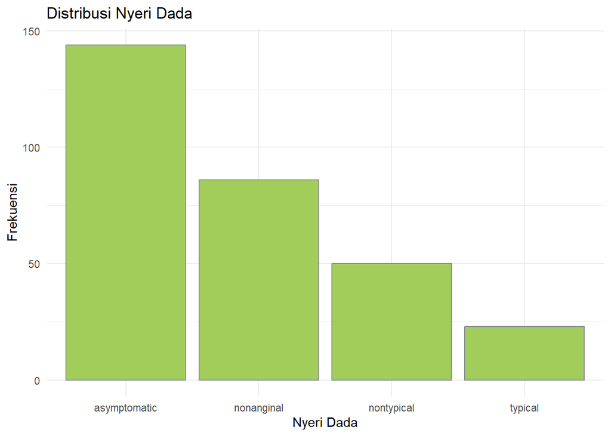

```r
ggplot(heart, aes(x=ChestPain))+
  geom_bar(fill="darkolivegreen3", color="azure4")+
  theme_minimal()+
  labs(x="Nyeri Dada", y="Frekuensi", title="Distribusi Nyeri Dada")
```

## 2. Tampilkan bar chart seperti pada gambar diatas, ganti skala y dengan persentase

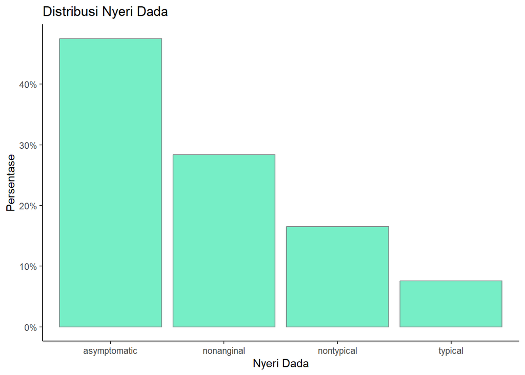

```r
ggplot(heart, aes(x=ChestPain,
                  y=..count.. / sum(..count..)))+
  geom_bar(fill="aquamarine2", color="azure4")+
  theme_classic()+
  labs(x="Nyeri Dada", y="Persentase", title="Distribusi Nyeri Dada")+
  scale_y_continuous(labels=scales::percent)
```

plot ini menunjukkan distribusi frekuensi jenis nyeri dada berdasarkan kategori ChestPain dalam dataset “heart,” tetapi kali ini skala sumbu y diubah menjadi persentase, dan angka pada sumbu y ditampilkan dalam format persentase.

## 3. Urutkan bar chart dari yang terkecil ke terbesar. Gunakan package dplyr dan ggplot

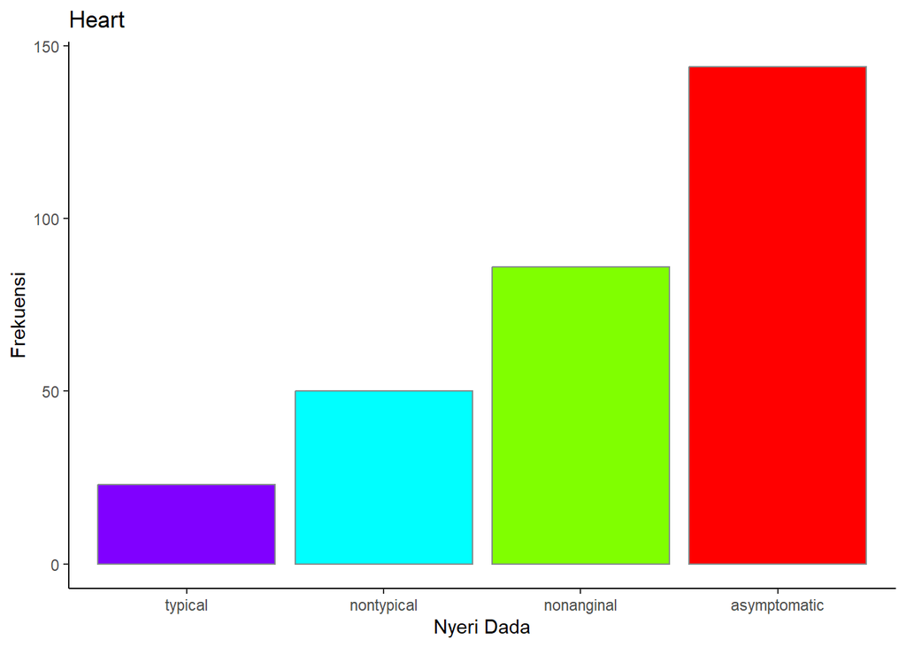

```r
plotdata=heart%>%count(ChestPain)
ggplot(plotdata, aes(x=reorder(ChestPain, n), y=n))+
  geom_bar(stat="Identity", fill=rainbow(4), color="azure4")+
  theme_classic()+
  labs(x="Nyeri Dada", y="Frekuensi", title="Heart")
```

Pada Barplot diatas, kita menggunakan package dplyr dan ggplot Barplot diurutkan dari jumlah frekuensi terkecil ke tertinggi, dalam hal ini saya menggunakan rainbow dalam pewarnaannya.

## 4. Berikan label dengan nilai numerik pada setiap chart, dengan mengurutkan dari presentase terbesar ke terkecil, pada sumbu X buat label miring dengan 45 derajat

```r
library(scales)
```

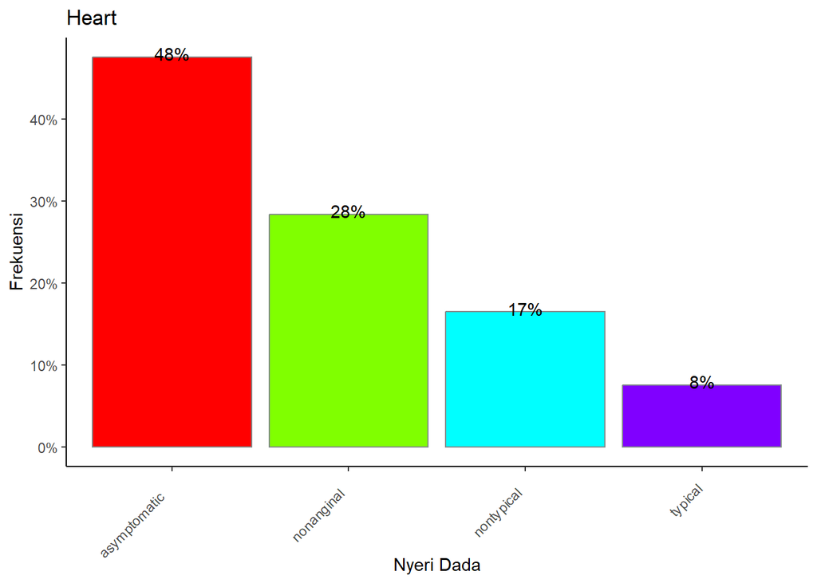

```r
plotdata=heart%>%
  count(ChestPain)%>%
  mutate(pct=n/sum(n),
         pctlabel=paste0(round(pct*100), '%'))
ggplot(plotdata, aes(x=reorder(ChestPain, -pct),
                     y=pct))+
  geom_bar(stat="Identity", fill=rainbow(4), color="azure4")+
  geom_text(aes(label=pctlabel),
            vjust=0.25)+
  scale_y_continuous(labels=scales::percent)+
  theme_classic()+
  labs(x="Nyeri Dada", y="Frekuensi", title="Heart")+
  theme(axis.text.x = element_text(angle = 45, hjust = 1.25))
```

Kode tersebut digunakan untuk membuat grafik batang yang menunjukkan frekuensi jenis nyeri dada dalam dataset “heart” dengan pengaturan tampilan grafik, label sumbu, dan label persentase menggunakan fungsi ‘scales’, serta memiringkan label sumbu x sebesar 45 derajat.

## 5. Transpose sumbu x dan sumbu y

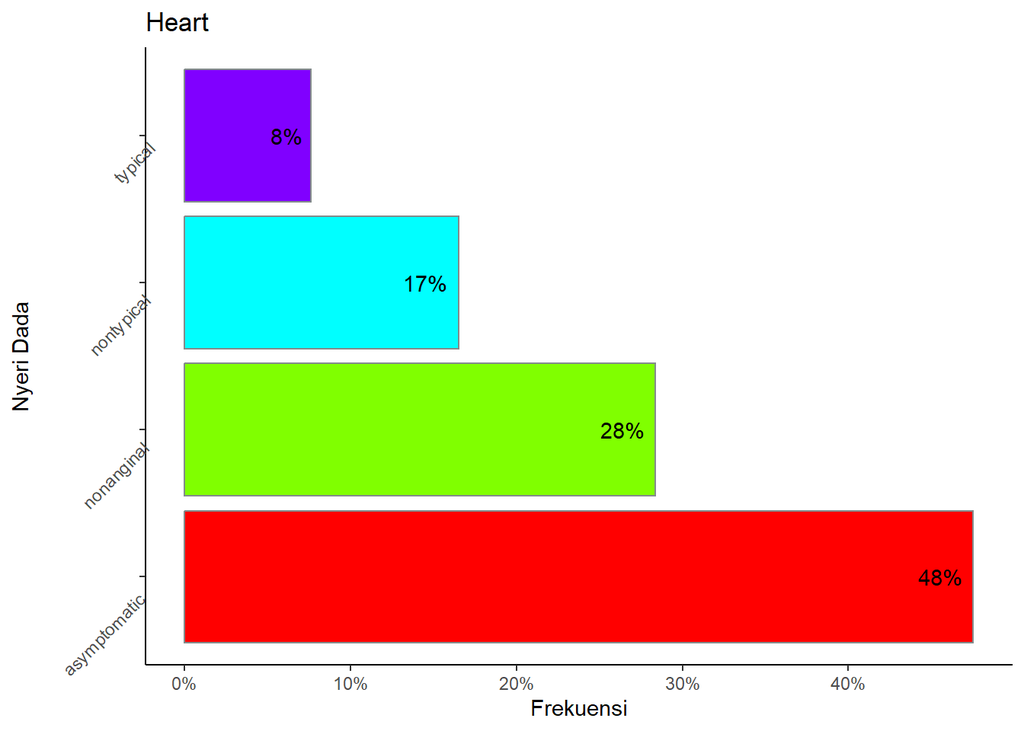

```r
ggplot(plotdata, aes(x=pct, y=reorder(ChestPain, -pct)))+
  geom_bar(stat="Identity", fill=rainbow(4), color="azure4")+
  geom_text(aes(label=pctlabel),
            hjust=1.25)+
  scale_x_continuous(labels=scales::percent)+
  theme_classic()+
  labs(x="Frekuensi", y="Nyeri Dada", title="Heart")+
  theme(axis.text.y = element_text(angle = 45, hjust = 1.25))
```

plot diatas sama seperti plot sebelumnya dimana kita menggunakan kolom frekuensi dalam bentuk persen. Perbedaannya hanya sumbu x dan sumbu y yang ditukar posisi

## 6. Buat pie chart berdasarkan Thal

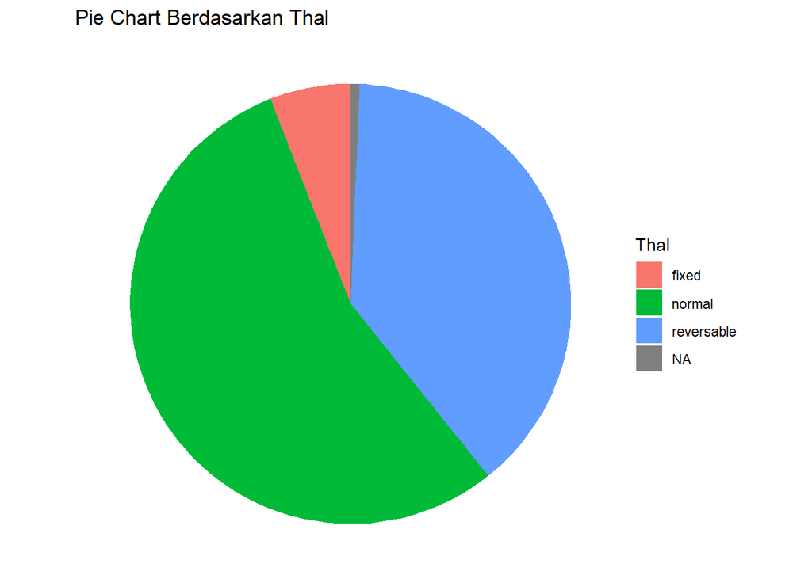

```r
thal_counts <- heart %>%
  count(Thal)
ggplot(thal_counts, aes(x = "", y = n, fill = Thal)) +
  geom_bar(stat = "identity", width = 1) +
  coord_polar("y", start = 0) +
  theme_void() +
  labs(fill = "Thal", y = "Frekuensi", title = "Pie Chart Berdasarkan Thal")
```

Dapat kita lihat, diatas merupakan pie chart yang dibuat berdasarkan “Thal” dan terbagi kedalam 4 jenis. Pie chart digunakan untuk menampilkan presentasi dari jumlah keseluruhan data.

## 7. Buat histogram berdasarkan Age

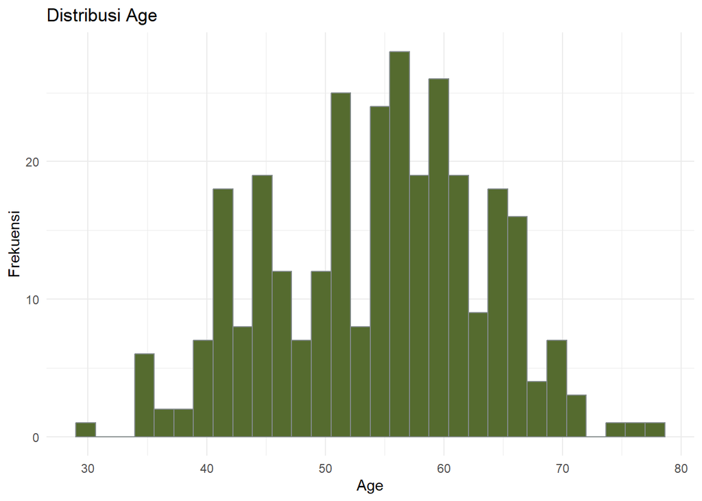

```r
ggplot(heart, aes(x=Age)) +
  geom_histogram(fill="darkolivegreen", color="azure4") +
  theme_minimal() +
  labs(x="Age", y="Frekuensi", title="Distribusi Age")
```